```python
import tensorflow as tf
import keras as keras
import os
from PIL import Image
from skimage import io
import numpy as np
import cv2
import math
import matplotlib.pyplot as plt
import seaborn as sns
import pandas as pd

from tensorflow.keras.layers import Input, Conv2D, Dense, Flatten, Dropout, GlobalMaxPooling2D, MaxPooling2D, BatchNormalization
from tensorflow.keras.optimizers import Adam, SGD
from tensorflow.keras.models import Model

from sklearn.metrics import confusion_matrix
import itertools
```

# Leukemia Cell Image Classification

#### Marian Lu, STAT 479 Final Exam

Objective: Building, evaluating, and interpreting a Convolutional Neural Network (CNN) to classify cells as leukemia blasts or normal using microscopy images.

## 1 Data Preprocessing

### 1.1 Data Selection

#### Introduction

The dataset is provided by Kaggle and contains images of cells segmented from microscopic images. These cells are representative of images in the real-world because they contain some staining noise and illumination errors, although these errors have largely been fixed in the course of acquisition. In total there are 15,135 images from 118 patients, which are categorized into two labelled classes: normal cells, and leukemia blasts.

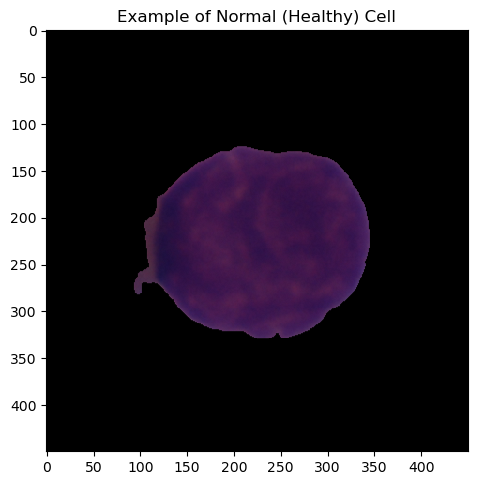

```python
io.imshow(os.path.join('data','fold_0', 'all', 'UID_1_1_1_all.bmp'))
plt.title('Example of Normal (Healthy) Cell')
```

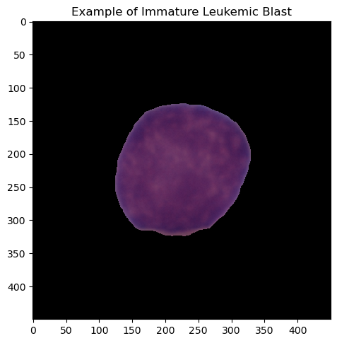

```python
io.imshow(os.path.join('data','fold_0', 'hem', 'UID_H7_1_1_hem.bmp'))
plt.title('Example of Immature Leukemic Blast')
```

To the untrained eye, these images appear very similar. However a CNN will be able to discover the complex patterns of the cell through feature mapping and filtering. Acute lymphoblastic leukemia (ALL) is the most common type of childhood cancer and accounts for approximately 25% of the pediatric cancers, so being able to efficiently and accurately detect signs of ALL will lead to game-changing advances in healthcare.

#### Data Distribution

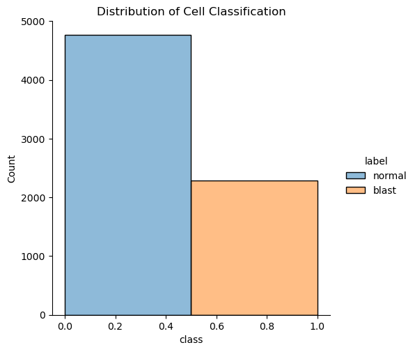

```python
classes = np.concatenate([y_train, y_test, y_val], axis=0)
classes = classes.tolist()
labs = ['normal' if x== 0 else 'blast' for x in classes]
df = pd.DataFrame({'class': classes, 'label': labs})
sns.displot(data=df, x='class', bins=2, hue='label')
plt.title('Distribution of Cell Classification')
```

There seems to be an imbalance of classes, favoring normal cells over leukemia blasts. Class imbalance can lead neural networks to make predictions biased towards the majority class. This issue will be adressed in a later section.

### 1.2 Preprocessing Images

All the images are 450x450 pixels. This is rather large, so they will be scaled down to 128x128 pixels for more optimal processing in later steps of training. The original images are also in color, so a grayscale will be applied to simply the network architecture. The images are organized in the following folder structure: fold_n (representing the patient cohort) -> [all (normal cells), hem (leukemia blasts)]. For more lightweight processing, instead of using the full dataset of over 15,000 images, I will be using fold_0 as training data, and splitting fold_1 for testing and validation data.

```python
def read_images(fold_n, img_class):
    dirpath = os.path.join('data', fold_n, img_class)
    all_images = []
    for i in os.listdir(dirpath):
        image_path = os.path.join('data', fold_n, img_class, i)
        img = io.imread(image_path, as_gray=True)
        all_images.append(cv2.resize(img, (128, 128)))

    X = np.array(all_images)

    return X
```

```python
# reading in images from fold_0 and fold_1
X_all0 = read_images('fold_0', 'all')
X_hem0 = read_images('fold_0', 'hem')
X_all1 = read_images('fold_1', 'all')
X_hem1 = read_images('fold_1', 'hem')
```

### 1.3 Data Splitting

There are a total of **7057 observations** in the selected data. The data will be split into 3 subsets with a 50-25-25 split: training (3527), testing (1765), and validation (1765).

```python
# allocating fold_0 images for training, and splitting fold_1 images for testing and validation
x_train = np.concatenate([X_all0, X_hem0], axis=0)
x_train = np.expand_dims(x_train, -1)
y_train = np.concatenate([np.repeat(0, len(X_all0), axis=0),
                          np.repeat(1, len(X_hem0), axis=0)], axis=0)

sub_all = np.split(X_all1[:-1], 2)
sub_hem = np.split(X_hem1[:-1], 2)

x_test  = np.concatenate([sub_all[0], sub_hem[0]], axis=0)
x_test  = np.expand_dims(x_test, -1) #adding new dimemension to x_test
y_test  = np.concatenate([np.repeat(0, len(sub_all[0]), axis=0), np.repeat(1, len(sub_hem[0]), axis=0)], axis=0)

x_val   = np.concatenate([sub_all[1], sub_hem[1]], axis=0)
x_val   = np.expand_dims(x_val, -1)
y_val   = np.concatenate([np.repeat(0, len(sub_all[1]), axis=0), np.repeat(1, len(sub_hem[1]), axis=0)], axis=0)

x_train, x_test, x_val = x_train/128, x_test/128, x_val/128 # normalizing pixel values to range (0, 1)

print('Training data shape:', x_train.shape)
print('Testing data shape:', x_test.shape)
print('Validation data shape:', x_val.shape)
```

```
Training data shape: (3527, 128, 128, 1)
Testing data shape: (1765, 128, 128, 1)
Validation data shape: (1765, 128, 128, 1)
```

## 2 Model Design and Implementation

### 2.1 Defining CNN

The structure of a CNN consists of the following:

- Input Layer - Images are read in to the network, usually as numerical arrays.
- Convolutional Layers - Filters are used to extract features from the input image. This is where the network recognizes general patterns.
- Pooling Layers - These are used to decrease dimensions of feature maps to reduce complexity and reduce overfitting.
- Fully Connected Layers - This layer connects all neurons from the previous layer and is able to recognize and respond to high-level features
- Output Layer - Returns the output of the neural network. In this case, it will be returning either 0 or 1, since this is a binary classification task.

#### Initial Model Parameters

- **Number of filters 1:** 32
- **Number of filters 2:** 64
- **Number of filters 3:** 128
- **Dropout Rate:** 0.2
- **Learning Rate:** 0.001
- **Density Units:** 512
- **Epochs:** 15
- **Optimizer: Adam**

```python
# Build the model using the functional API
i = Input(shape=x_train[0].shape)
x = Conv2D(32, (3, 3), strides=2, activation='relu')(i) # 32 filters of 3x3 size filter; The first convolutional layer (Conv2D) takes input i.
x = Conv2D(64, (3, 3), strides=2, activation='relu')(x)
# The strides=2 argument reduces the spatial dimensions (width and height) of the feature maps by approximately half, similar to the effect of pooling.
# If the input feature map has dimensions 28×28, applying a convolution layer with strides=2 results in an output feature map of approximately 14×14.
x = Conv2D(128, (3, 3), strides=2, activation='relu')(x)
x = Flatten()(x) # Flattens the 2D feature maps from convolutional layers into a 1D vector before Dense layer
x = Dropout(.2)(x)
x = Dense(512, activation='relu')(x)
x = Dropout(.2)(x)
x = Dense(2, activation='softmax')(x)

model = Model(i, x) # Creates a Keras model by specifying the input tensor (i) and output tensor (x).
```

```python
model.compile(optimizer='adam', loss='sparse_categorical_crossentropy', metrics=['accuracy'])
r = model.fit(x_train, y_train, validation_data=(x_test, y_test), epochs=15, verbose=0)
```

```python
print('Accuracy:', round(r.history['accuracy'][-1], 4))
print('Validation Accuracy:', round(r.history['val_accuracy'][-1], 4))
```

```
Accuracy: 0.8166
Validation Accuracy: 0.7507
```

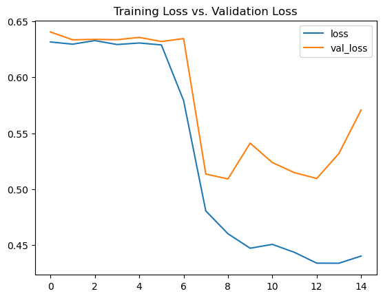

```python
# Evaluating with Loss
plt.plot(r.history['loss'], label='loss')
plt.plot(r.history['val_loss'], label='val_loss')
plt.title('Training Loss vs. Validation Loss')
plt.legend()
```

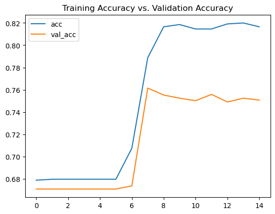

```python
# Evaluating with Accuracy
plt.plot(r.history['accuracy'], label='acc')
plt.plot(r.history['val_accuracy'], label='val_acc')
plt.title('Training Accuracy vs. Validation Accuracy')
plt.legend()
```

#### Initial Model Summary

- **Accuracy:** 0.8166
- **Validation Accuracy:** 0.7507  
  Starting out with the most basic settings, the model seems to have adequate performance, as its accuracy is decently high. The validation accuracy also shows favorable results, indicating the model's ability to generalize on new data. There seems to be a clear divergence around 7 epochs in both the loss and accuracy curve plots.

### 2.2 Model Iterations

Moving forward with the model, I decided to handle the class imbalance by downsampling the majority class. After resampling the data, the distribution of the target variable is more even, and should help the model reduce bias towards the majority class. All subsequent iterations of the model are trained on the new downsampled data.

```
Down sampled training data shape: (2328, 128, 128, 1)
```

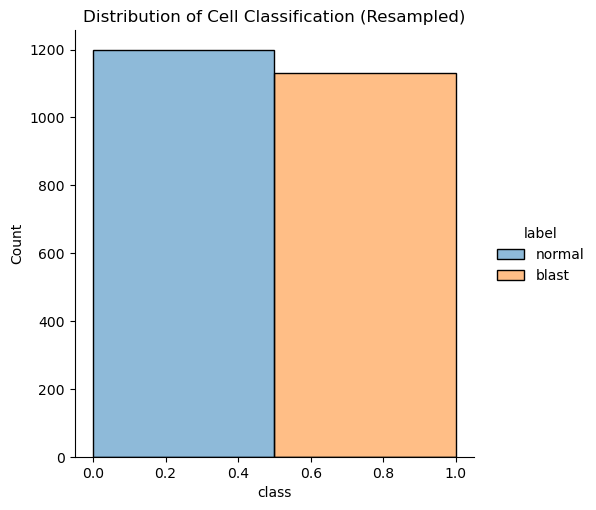

```python
# downsampling the data by reducing the majority class
new_x_len = math.floor(len(X_all0)*0.5)
x_train_ds = np.concatenate([X_all0[:new_x_len], X_hem0], axis=0)
x_train_ds = np.expand_dims(x_train_ds, -1)
y_train_ds = np.concatenate([np.repeat(0, new_x_len, axis=0),
                             np.repeat(1, len(X_hem0), axis=0)], axis=0)

print('Down sampled training data shape:', x_train_ds.shape)

classes = y_train_ds.tolist()
labs = ['normal' if x== 0 else 'blast' for x in classes]
df = pd.DataFrame({'class': classes, 'label': labs})
sns.displot(data=df, x='class', bins=2, hue='label')
plt.title('Distribution of Cell Classification (Resampled)')
```

#### Iteration 1

The loss plots from the initial model seemed like it converged too fast, so I lowered the learning rate and switched the optimizer to SGD (Stochastic Gradient Descent) so that I could implement momentum. Momentum is an extension to the gradient descent optimization algorithm, and is used to accelerate the optimization process. Lastly, the loss and accuracy plots from the initial model showed a clear divergence around epochs=7, so epochs are set to 7.

- **Number of filters 1:** 32
- **Number of filters 2:** 64
- **Number of filters 3:** 128
- **Dropout Rate:** 0.2
- **Learning Rate:** 0.0001
- **Density Units:** 512
- **Epochs:** 7
- **Optimizer: SGD**

```python
i = Input(shape=x_train_ds[0].shape)
x = Conv2D(32, (3, 3), strides=2, activation='relu')(i)
x = Conv2D(64, (3, 3), strides=2, activation='relu')(x)
x = Conv2D(128, (3, 3), strides=2, activation='relu')(x)
x = Flatten()(x)
x = Dropout(.2)(x)
x = Dense(512, activation='relu')(x)
x = Dropout(.2)(x)
x = Dense(2, activation='softmax')(x)

new_model = Model(i, x)
```

```python
optimizer = SGD(learning_rate=0.0001, momentum=0.5)
new_model.compile(optimizer=optimizer, loss='sparse_categorical_crossentropy', metrics=['accuracy'])
r1 = new_model.fit(x_train_ds, y_train_ds, validation_data=(x_test, y_test), epochs=7, verbose=0)
```

```python
print('Accuracy:', round(r1.history['accuracy'][-1], 4))
print('Validation Accuracy:', round(r1.history['val_accuracy'][-1], 4))
```

```
Accuracy: 0.5619
Validation Accuracy: 0.3292
```

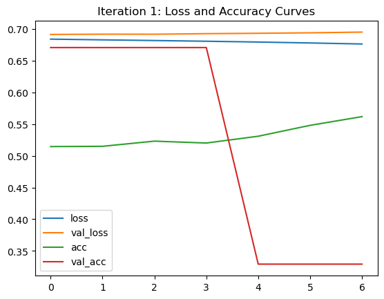

```python
plt.plot(r1.history['loss'], label='loss')
plt.plot(r1.history['val_loss'], label='val_loss')
plt.plot(r1.history['accuracy'], label='acc')
plt.plot(r1.history['val_accuracy'], label='val_acc')
plt.title('Iteration 1: Loss and Accuracy Curves')
plt.legend()
```

#### Iteration 1 Summary

- **Accuracy:** 0.5619
- **Validation Accuracy:** 0.3292  
  The model's performance dropped significantly from the initial model.

#### Iteration 2

- **Number of filters 1:** 32
- **Number of filters 2:** 64
- **Number of filters 3:** 128
- **Dropout Rate:** 0.2
- **Learning Rate:** 0.005
- **Density Units:** 512
- **Epochs:** 7
- **Optimizer:** Adam

```python
i = Input(shape=x_train_ds[0].shape)
x = Conv2D(32, (3, 3), strides=2, activation='relu')(i)
x = Conv2D(64, (3, 3), strides=2, activation='relu')(x)
x = Conv2D(128, (3, 3), strides=2, activation='relu')(x)
x = Flatten()(x)
x = Dropout(.2)(x)
x = Dense(512, activation='relu')(x)
x = Dropout(.2)(x)
x = Dense(2, activation='softmax')(x)

new_model = Model(i, x)
```

```python
optimizer = Adam(learning_rate=0.005)
new_model.compile(optimizer=optimizer, loss='sparse_categorical_crossentropy', metrics=['accuracy'])
r2 = new_model.fit(x_train_ds, y_train_ds, validation_data=(x_test, y_test), epochs=7)
```

```
73/73 ━━━━━━━━━━━━━━━━━━━━ 12s 140ms/step - accuracy: 0.7759 - loss: 0.4899 - val_accuracy: 0.3292 - val_loss: 0.8041
73/73 ━━━━━━━━━━━━━━━━━━━━ 10s 131ms/step - accuracy: 0.7916 - loss: 0.4762 - val_accuracy: 0.3292 - val_loss: 0.7944
73/73 ━━━━━━━━━━━━━━━━━━━━ 9s 127ms/step - accuracy: 0.7835 - loss: 0.4962 - val_accuracy: 0.3292 - val_loss: 0.8523
73/73 ━━━━━━━━━━━━━━━━━━━━ 9s 125ms/step - accuracy: 0.7917 - loss: 0.4758 - val_accuracy: 0.3292 - val_loss: 0.8484
73/73 ━━━━━━━━━━━━━━━━━━━━ 9s 126ms/step - accuracy: 0.8083 - loss: 0.4328 - val_accuracy: 0.3292 - val_loss: 0.8516
73/73 ━━━━━━━━━━━━━━━━━━━━ 9s 127ms/step - accuracy: 0.7866 - loss: 0.4730 - val_accuracy: 0.3292 - val_loss: 0.9829
73/73 ━━━━━━━━━━━━━━━━━━━━ 9s 127ms/step - accuracy: 0.7977 - loss: 0.4388 - val_accuracy: 0.3292 - val_loss: 0.7756
```

```python
print('Accuracy:', round(r2.history['accuracy'][-1], 3))
print('Training Accuracy:', round(r2.history['val_accuracy'][-1], 3))
```

```
Accuracy: 0.81
Training Accuracy: 0.329
```

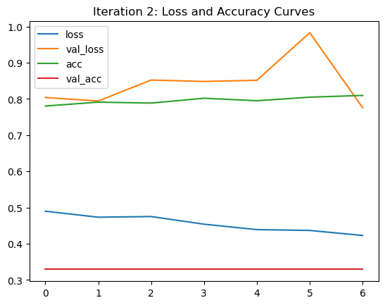

```python
plt.plot(r2.history['loss'], label='loss')
plt.plot(r2.history['val_loss'], label='val_loss')
plt.plot(r2.history['accuracy'], label='acc')
plt.plot(r2.history['val_accuracy'], label='val_acc')
plt.title('Iteration 2: Loss and Accuracy Curves')
plt.legend()
```

#### Iteration 2 Summary

- **Accuracy:** 0.8100
- **Validation Accuracy:** 0.3292

The model's performance improved from Iteration 1, but is still outperformed by the initial model. While the accuracy showed a significant increase, the validation accuracy stayed stagnant through the training process. Iteration 2 shows promise in its predictive ability but it unable to generalize on new data.

### 2.3 Model Selection

**Final Model**

- **Number of filters 1:** 32
- **Number of filters 2:** 64
- **Number of filters 3:** 128
- **Dropout Rate:** 0.2
- **Learning Rate:** 0.001
- **Density Units:** 512
- **Epochs:** 15
- **Optimizer: Adam**

**Accuracy:** 0.8166  
**Validation Accuracy:** 0.7507

Unfortunately, none of the optimization strategies seemed to work, as the initial model outperformed all subsequent iterations. The final model is the same as the initial model since it has favorable accuracy as well as being adaptable to new data.

## 3 Model Evaluation and Interpretation

### 3.1 ROC Curve and AUC

The Receiver Operator Characteristic (ROC) Curve is a metric for evaluating binary classificaiton models. It shows the performance of the model at all thresholds. A perfect ROC curve would resemble a right angle in upper left diagonal of the plot. The ideal AUC (area under curve) would be 1, since it means that the model has 100% accuracy.

```
56/56 ━━━━━━━━━━━━━━━━━━━━ 1s 19ms/step
```

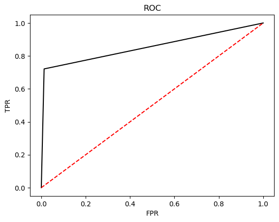

```
AUC score: 0.854250738475136
```

```python
from sklearn.metrics import roc_curve, roc_auc_score

y_score = model.predict(x_val).argmax(axis=1)
fpr, tpr, thresholds = roc_curve(y_val, y_score)
plt.plot(fpr, tpr, 'k')
plt.plot([0, 1], [0, 1], 'r--')
plt.xlabel('FPR')
plt.ylabel('TPR')
plt.title('ROC')
plt.show()
print('AUC score:', roc_auc_score(y_test, y_score))
```

### 3.2 Confusion Matrix

```
56/56 ━━━━━━━━━━━━━━━━━━━━ 1s 19ms/step
Confusion matrix, without normalizaiton
[[1169   15]
 [ 162  419]]
```

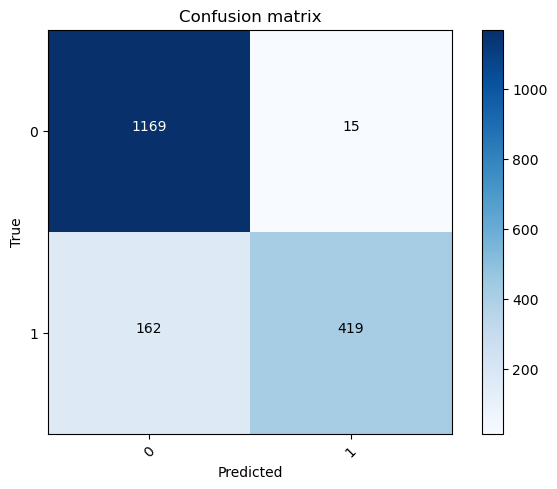

```python
def plot_confusion_matrix(cm, classes, normalize=False, title='Confusion matrix', cmap=plt.cm.Blues):
    """
    This funciton prints and plots the confusion matrix.
    Normalization can be applied by setting 'normalize=True'.
    """
    if normalize:
        cm = cm.astype('float')/cm.sum(axis=1)[:, np.newaxis]
        print("Normalized confusion matrix")
    else:
        print('Confusion matrix, without normalizaiton')
    print(cm)

    plt.imshow(cm, interpolation='nearest', cmap=cmap)
    plt.title(title)
    plt.colorbar()
    tick_marks = np.arange(len(classes))
    plt.xticks(tick_marks, classes, rotation=45)
    plt.yticks(tick_marks, classes)

    fmt = '.2f' if normalize else 'd'
    thresh = cm.max()/2.
    for i, j in itertools.product(range(cm.shape[0]), range(cm.shape[1])):
        plt.text(j, i, format(cm[i,j], fmt), horizontalalignment="center",
                 color="white" if cm[i,j] > thresh else "black")
    plt.tight_layout()
    plt.ylabel('True')
    plt.xlabel('Predicted')
    plt.show()

p_test = model.predict(x_val).argmax(axis=1)
cm = confusion_matrix(y_val, p_test)
plot_confusion_matrix(cm, [0, 1])
```

Based on the confusion matrix, the model has decent accuracy. However, it still seems to favor the majority class, predicting false negatives at a rate 10 times higher than it predicts false positives. This is likely a result of being trained on unbalanced data. In the context of disease classification, it is generally better to predict more false positives over false negatives, since the main objective is to detect the presence of diseases.

## 4 Conclusion

The initial model remained the top performer throughout the selection process. It exceeded the other iterations with its high accuracy and versatility. Some of the difficulties during this process was dealing with how resource-intensive CNN training was. I initially wanted to try hyperparameter tuning using random search, but I kept getting timeout errors, so I had to resort to manually tuning the hyperparameters. With better hardware, the model iterations could have been more throroghly optimized and outperformed the initial model, which still has a lot of room for improvement. However, in the context of the problem, a final accuracy of 81% is respectable, especially since the images were from real world data. Further development of this CNN can lead to earlier detection of Acute lymphoblastic leukemia, more personalized treatments, and improved patient outcomes, especially in resource-limited settings.